# Measures of association Homework

Tim Hulak

I produced the material below with no assistance

# Exercises 3,4, 8, 9, and 10 on pages 155 and 156 of *Reasoning with Data: An Introduction to Traditional and Bayesian Statistics Using R*

3. Run cor.test() on the correlation between “area” and “perm” in the rock data set and interpret the results. Note that you will have to use the “$” accessor to get at each of the two variables (like this: rock$area). Make sure that you interpret both the confidence interval and the p-value that is generated by cor.test().

```r
options(scipen=999)
data("rock")
head(rock)
```

|  | area | peri | shape | perm |
| --- | --- | --- | --- | --- |
| 1 | 4990 | 2791.90 | 0.0903296 | 6.3 |
| 2 | 7002 | 3892.60 | 0.1486220 | 6.3 |
| 3 | 7558 | 3930.66 | 0.1833120 | 6.3 |
| 4 | 7352 | 3869.32 | 0.1170630 | 6.3 |
| 5 | 7943 | 3948.54 | 0.1224170 | 17.1 |
| 6 | 7979 | 4010.15 | 0.1670450 | 17.1 |

```r
cor.test(rock$area,rock$perm)
```

```
##
##  Pearson's product-moment correlation
##
## data:  rock$area and rock$perm
## t = -2.9305, df = 46, p-value = 0.005254
## alternative hypothesis: true correlation is not equal to 0
## 95 percent confidence interval:
##  -0.6118206 -0.1267915
## sample estimates:
##       cor
## -0.396637
```

4. Create a copy of the bfCorTest() custom function presented in this chapter. Don’t forget to “source” it (meaning that you have to run the code that defines the function one time to make R aware of it). Conduct a Bayesian analysis of the correlation between “area” and “perm” in the rock data set.

```r
#Copied from the book:
# Reasoning with Data: An Introduction to Traditional and Bayesian Statistics Using R
# Stanton, Jeffrey M.. Reasoning with Data (p. 136). Guilford Publications. Kindle Edition.
library("BayesFactor")
bfCorTest <- function (x,y) #Get r from BayesFactor
{  zx <- scale(x) #Standardize X
  zy <- scale(y) #Standardize Y
  zData <- data.frame(x=zx,rhoNot0=zy) #Put in a data frame
  bfOut <- generalTestBF(x ~ rhoNot0, data=zData) #linear coefficient
  mcmcOut <- posterior(bfOut,iterations=10000) #posterior samples
  print(summary(mcmcOut[,"rhoNot0"])) #Show the HDI for r
  return(bfOut) #Return Bayes factor object
  }

bfCorTest(rock$area,rock$perm)
```

```
##
## Iterations = 1:10000
## Thinning interval = 1
## Number of chains = 1
## Sample size per chain = 10000
##
## 1. Empirical mean and standard deviation for each variable,
##    plus standard error of the mean:
##
##           Mean             SD       Naive SE Time-series SE
##      -0.345705       0.135357       0.001354       0.001511
##
## 2. Quantiles for each variable:
##
##     2.5%      25%      50%      75%    97.5%
## -0.61601 -0.43392 -0.34435 -0.25419 -0.08529
```

```
## Bayes factor analysis
## --------------
## [1] rhoNot0 : 8.072781 ±0%
##
## Against denominator:
##   Intercept only
## ---
## Bayes factor type: BFlinearModel, JZS
```

8. Not unexpectedly, there is a data set in R that contains these data. The data set is called UCBAdmissions and you can access the department mentioned above like this: UCBAdmissions[, ,1]. Make sure you put two commas before the 1: this is a three dimensional contingency table that we are subsetting down to two dimensions. Run chisq.test() on this subset of the data set and make sense of the results.

```r
data('UCBAdmissions')
UCBAdmissions[, ,1]
```

```
##           Gender
## Admit      Male Female
##   Admitted  512     89
##   Rejected  313     19
```

```r
chisq.test(UCBAdmissions[,,1], correct=F)
```

```
##
##  Pearson's Chi-squared test
##
## data:  UCBAdmissions[, , 1]
## X-squared = 17.248, df = 1, p-value = 0.0000328
```

**Answer**: The output of the *Pearson’s Chi-squared test* shows a *chi-squared* value of **17.248** with only **1** *degree of freedom*. The *p-value* is **0.0000328**, which is less than the traditional alpha of **0.05**. This means that we can reject the null hypothesis and conclude that gender and admit are not independent of each other.

9. Use contingencyTableBF() to conduct a Bayes factor analysis on the UCB admissions data. Report and interpret the Bayes factor.

```r
admission_table <- contingencyTableBF(UCBAdmissions[,,1],sampleType="poisson", posterior=F)
summary(admission_table)
```

```
## Bayes factor analysis
## --------------
## [1] Non-indep. (a=1) : 1111.64 ±0%
##
## Against denominator:
##   Null, independence, a = 1
## ---
## Bayes factor type: BFcontingencyTable, poisson
```

10. Using the UCBA data, run contingencyTableBF() with posterior sampling. Use the results to calculate a 95% HDI of the difference in proportions between the columns.

```r
admission_table_posterior <- contingencyTableBF(UCBAdmissions[,,1], sampleType="poisson", posterior=T, iterations = 10000)
summary(admission_table_posterior)
```

```
##
## Iterations = 1:10000
## Thinning interval = 1
## Number of chains = 1
## Sample size per chain = 10000
##
## 1. Empirical mean and standard deviation for each variable,
##    plus standard error of the mean:
##
##               Mean     SD Naive SE Time-series SE
## lambda[1,1] 510.56 22.637  0.22637        0.23052
## lambda[2,1] 312.68 17.583  0.17583        0.17583
## lambda[1,2]  89.58  9.449  0.09449        0.09449
## lambda[2,2]  19.91  4.460  0.04460        0.04443
##
## 2. Quantiles for each variable:
##
##               2.5%    25%    50%    75% 97.5%
## lambda[1,1] 466.04 495.12 510.30 525.81 555.9
## lambda[2,1] 279.02 300.74 312.22 324.43 348.2
## lambda[1,2]  72.03  83.03  89.21  95.74 109.0
## lambda[2,2]  12.20  16.76  19.55  22.70  29.7
```

```r
head(admission_table_posterior)
```

```
## Markov Chain Monte Carlo (MCMC) output:
## Start = 1
## End = 7
## Thinning interval = 1
##      lambda[1,1] lambda[2,1] lambda[1,2] lambda[2,2]
## [1,]    482.4104    304.6770   105.43309    17.61580
## [2,]    515.6504    308.0501    89.08307    20.27055
## [3,]    496.8955    276.9641    89.65067    13.87057
## [4,]    508.2965    332.1067    91.96127    20.85768
## [5,]    533.9877    295.6031    81.64745    19.22796
## [6,]    567.0088    308.1764    85.98405    21.21051
## [7,]    468.8586    306.6118    79.01263    12.63960
```

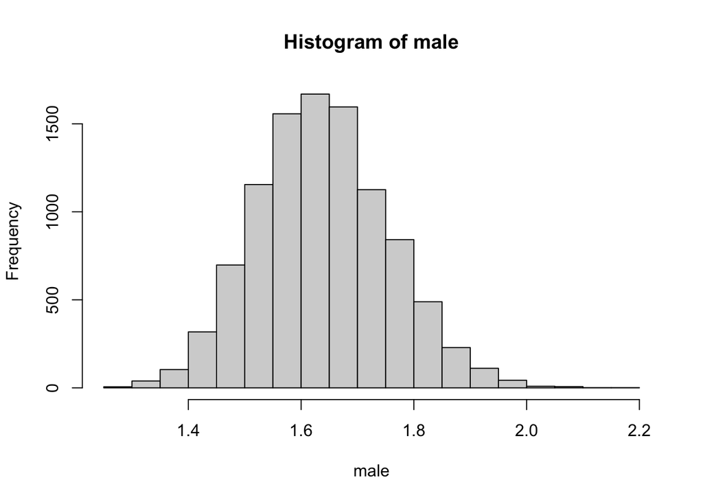

```r
male <- admission_table_posterior[,"lambda[1,1]"]/admission_table_posterior[,"lambda[2,1]"]
hist(male)
```

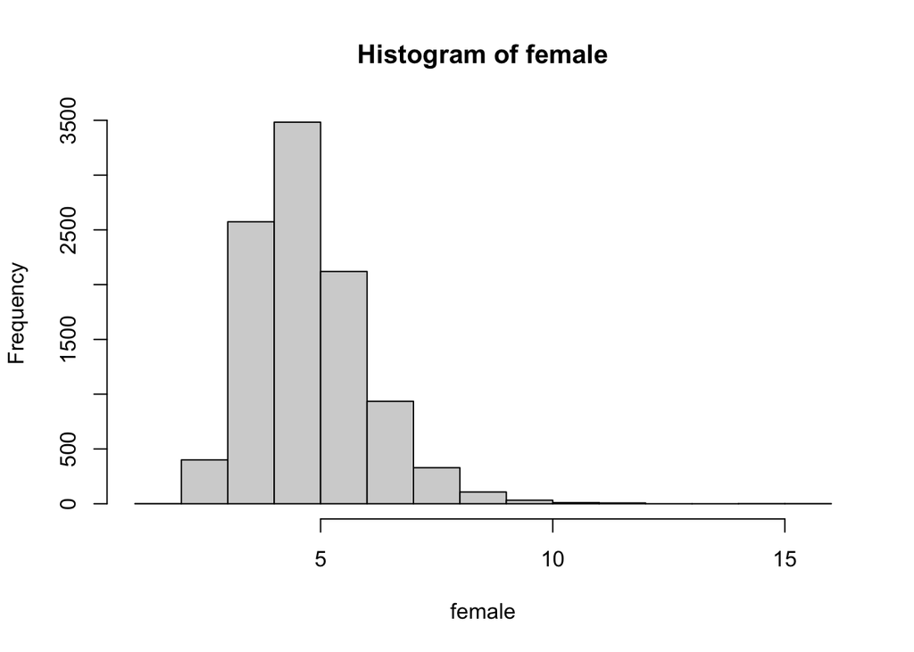

```r
female <- admission_table_posterior[,"lambda[1,2]"]/admission_table_posterior[,"lambda[2,2]"]
hist(female)
```

```r
difference <- male - female
head(difference)
```

```
## Markov Chain Monte Carlo (MCMC) output:
## Start = 1
## End = 7
## Thinning interval = 1
## [1] -4.401794 -2.720788 -4.669294 -2.878466 -2.439854 -2.213958 -4.722036
```

```r
c(quantile(difference,c(0.025)),quantile(difference,c(0.975)))
```

```
##      2.5%     97.5%
## -5.971812 -1.198974
```